# Introduction to Pandas

### Pandas Overview

Over the next couple of series, we are going to go through an overview of Pandas, a data manipulation package for python. Pandas has extensive, easy to use data manipulation capabilities that are useful for data transformation, preparation and analysis. Let's begin.

### Import Pandas

Convention is a powerful thing and you will notice that all pandas users import pandas the same way.

```python
# Importing Pandas
import pandas as pd

# Checking Pandas Version
pd.__version__
```

```
'0.20.1'
```

### Reading Data into a pandas object

Pandas allows us to read data in various formats and from various sources. General, people read in from a file and the only requirement is to pass the file path into the read methods available in pandas. Below is an example of reading from *csv* file.

```python
# Reading the Hotel's Review CSV file
data = pd.read_csv(r'/Volumes/Sifael/DS Templates/Data/titanic.csv')
```

### 1. Base Pandas Functionalities

### Data Info

A good way to check the contents of the data object is to use pandas **info()** method. The *info()* method provides a simple way to summarize the dataframe object, its content, data types and additional computing information.

```python
data.info()
```

```
<class 'pandas.core.frame.DataFrame'>
RangeIndex: 891 entries, 0 to 890
Data columns (total 12 columns):
PassengerId    891 non-null int64
Survived       891 non-null int64
Pclass         891 non-null int64
Name           891 non-null object
Sex            891 non-null object
Age            714 non-null float64
SibSp          891 non-null int64
Parch          891 non-null int64
Ticket         891 non-null object
Fare           891 non-null float64
Cabin          204 non-null object
Embarked       889 non-null object
dtypes: float64(2), int64(5), object(5)
memory usage: 83.6+ KB
```

### Shape

We can easily identify the shape of our dataframe by using the **shape** attribute. The shape method returns a tuple containing the number of rows and columns in the dataframe object.

```python
data.shape
```

```
(891, 12)
```

### Size

Pandas **size** attribute give the overall size of the number of columns and rows. For those with familiarity with matrices, this is equivalent to the size of a matrix. Mathematically, its the product of rows and columns.

```python
data.size
```

```
10692
```

### dtypes - data types

**dtypes** attribute allows us to return the data types for all the columns contained in the dataframe

```python
data.dtypes
```

```
PassengerId      int64
Survived         int64
Pclass           int64
Name            object
Sex             object
Age            float64
SibSp            int64
Parch            int64
Ticket          object
Fare           float64
Cabin           object
Embarked        object
dtype: object
```

### describe

Pandas **describe()** method returns some descriptive statistics about our dataframe. Often referred to as the 5 number summary, the **describe()** method provides this for numeric datatypes by default.

```python
data.describe()
```

|  | PassengerId | Survived | Pclass | Age | SibSp | Parch | Fare |
| --- | --- | --- | --- | --- | --- | --- | --- |
| count | 891.000000 | 891.000000 | 891.000000 | 714.000000 | 891.000000 | 891.000000 | 891.000000 |
| mean | 446.000000 | 0.383838 | 2.308642 | 29.699118 | 0.523008 | 0.381594 | 32.204208 |
| std | 257.353842 | 0.486592 | 0.836071 | 14.526497 | 1.102743 | 0.806057 | 49.693429 |
| min | 1.000000 | 0.000000 | 1.000000 | 0.420000 | 0.000000 | 0.000000 | 0.000000 |
| 25% | 223.500000 | 0.000000 | 2.000000 | 20.125000 | 0.000000 | 0.000000 | 7.910400 |
| 50% | 446.000000 | 0.000000 | 3.000000 | 28.000000 | 0.000000 | 0.000000 | 14.454200 |
| 75% | 668.500000 | 1.000000 | 3.000000 | 38.000000 | 1.000000 | 0.000000 | 31.000000 |
| max | 891.000000 | 1.000000 | 3.000000 | 80.000000 | 8.000000 | 6.000000 | 512.329200 |

Notice that in the above describe, pandas returned the summary of only numeric columns. Suppose we wanted to return the summary of all columns, here is a way to do it.

```python
data.describe(include='all')
```

|  | PassengerId | Survived | Pclass | Name | Sex | Age | SibSp | Parch | Ticket | Fare | Cabin | Embarked |
| --- | --- | --- | --- | --- | --- | --- | --- | --- | --- | --- | --- | --- |
| count | 891.000000 | 891.000000 | 891.000000 | 891 | 891 | 714.000000 | 891.000000 | 891.000000 | 891 | 891.000000 | 204 | 889 |
| unique | NaN | NaN | NaN | 891 | 2 | NaN | NaN | NaN | 681 | NaN | 147 | 3 |
| top | NaN | NaN | NaN | Andrews, Miss. Kornelia Theodosia | male | NaN | NaN | NaN | 347082 | NaN | C23 C25 C27 | S |
| freq | NaN | NaN | NaN | 1 | 577 | NaN | NaN | NaN | 7 | NaN | 4 | 644 |
| mean | 446.000000 | 0.383838 | 2.308642 | NaN | NaN | 29.699118 | 0.523008 | 0.381594 | NaN | 32.204208 | NaN | NaN |
| std | 257.353842 | 0.486592 | 0.836071 | NaN | NaN | 14.526497 | 1.102743 | 0.806057 | NaN | 49.693429 | NaN | NaN |
| min | 1.000000 | 0.000000 | 1.000000 | NaN | NaN | 0.420000 | 0.000000 | 0.000000 | NaN | 0.000000 | NaN | NaN |
| 25% | 223.500000 | 0.000000 | 2.000000 | NaN | NaN | 20.125000 | 0.000000 | 0.000000 | NaN | 7.910400 | NaN | NaN |
| 50% | 446.000000 | 0.000000 | 3.000000 | NaN | NaN | 28.000000 | 0.000000 | 0.000000 | NaN | 14.454200 | NaN | NaN |
| 75% | 668.500000 | 1.000000 | 3.000000 | NaN | NaN | 38.000000 | 1.000000 | 0.000000 | NaN | 31.000000 | NaN | NaN |
| max | 891.000000 | 1.000000 | 3.000000 | NaN | NaN | 80.000000 | 8.000000 | 6.000000 | NaN | 512.329200 | NaN | NaN |

### head

We can use the pandas **head** method to visualize the top n rows by passing a value n to the **head(n)**. By default, pandas gives us the top 5 rows.

```python
data.head()
```

|  | PassengerId | Survived | Pclass | Name | Sex | Age | SibSp | Parch | Ticket | Fare | Cabin | Embarked |
| --- | --- | --- | --- | --- | --- | --- | --- | --- | --- | --- | --- | --- |
| 0 | 1 | 0 | 3 | Braund, Mr. Owen Harris | male | 22.0 | 1 | 0 | A/5 21171 | 7.2500 | NaN | S |
| 1 | 2 | 1 | 1 | Cumings, Mrs. John Bradley (Florence Briggs Th... | female | 38.0 | 1 | 0 | PC 17599 | 71.2833 | C85 | C |
| 2 | 3 | 1 | 3 | Heikkinen, Miss. Laina | female | 26.0 | 0 | 0 | STON/O2. 3101282 | 7.9250 | NaN | S |
| 3 | 4 | 1 | 1 | Futrelle, Mrs. Jacques Heath (Lily May Peel) | female | 35.0 | 1 | 0 | 113803 | 53.1000 | C123 | S |
| 4 | 5 | 0 | 3 | Allen, Mr. William Henry | male | 35.0 | 0 | 0 | 373450 | 8.0500 | NaN | S |

### tail

```python
data.tail(5)
```

|  | PassengerId | Survived | Pclass | Name | Sex | Age | SibSp | Parch | Ticket | Fare | Cabin | Embarked |
| --- | --- | --- | --- | --- | --- | --- | --- | --- | --- | --- | --- | --- |
| 886 | 887 | 0 | 2 | Montvila, Rev. Juozas | male | 27.0 | 0 | 0 | 211536 | 13.00 | NaN | S |
| 887 | 888 | 1 | 1 | Graham, Miss. Margaret Edith | female | 19.0 | 0 | 0 | 112053 | 30.00 | B42 | S |
| 888 | 889 | 0 | 3 | Johnston, Miss. Catherine Helen "Carrie" | female | NaN | 1 | 2 | W./C. 6607 | 23.45 | NaN | S |
| 889 | 890 | 1 | 1 | Behr, Mr. Karl Howell | male | 26.0 | 0 | 0 | 111369 | 30.00 | C148 | C |
| 890 | 891 | 0 | 3 | Dooley, Mr. Patrick | male | 32.0 | 0 | 0 | 370376 | 7.75 | NaN | Q |

## 2. Slicing and Dicing

So far we have seen some initial capabilities of pandas in data exploration. Now, let's look at how we can slice and dice the dataframe to work with subsets of the data.

### columns

Suppose we want to know the columns in the dataframe, we can use the **columns** attribute to return a list of columns as follows:

```python
data.columns
```

```
Index(['PassengerId', 'Survived', 'Pclass', 'Name', 'Sex', 'Age', 'SibSp',
       'Parch', 'Ticket', 'Fare', 'Cabin', 'Embarked'],
      dtype='object')
```

### individual column selection

Now that we have the list of columns, we can select an indivual column. Similar to selecting an item from a list, we select a columns as seen below.

```python
data['Name'].head()
```

```
0                              Braund, Mr. Owen Harris
1    Cumings, Mrs. John Bradley (Florence Briggs Th...
2                               Heikkinen, Miss. Laina
3         Futrelle, Mrs. Jacques Heath (Lily May Peel)
4                             Allen, Mr. William Henry
Name: Name, dtype: object
```

Notice that if we are to determine the type returned above, it will yield **series**. A series object represent a single vector. Notice that it is no longer a dataframe and may not have dataframe functionalities.

```python
type(data['Name'])
```

```
pandas.core.series.Series
```

### selecting multiple columns

We can return multiple columns by passing a list of columns into the dataframe object index selection. For simplicity we return the first 5 items. Notice that with multiple columns, we are returning a dataframe object and not a series object

```python
data[['Name', 'Survived']].head()
```

|  | Name | Survived |
| --- | --- | --- |
| 0 | Braund, Mr. Owen Harris | 0 |
| 1 | Cumings, Mrs. John Bradley (Florence Briggs Th... | 1 |
| 2 | Heikkinen, Miss. Laina | 1 |
| 3 | Futrelle, Mrs. Jacques Heath (Lily May Peel) | 1 |
| 4 | Allen, Mr. William Henry | 0 |

### drop

Pandas allows us to drop both rows and columns as need. We use the **drop** to pass a list of columns we want to drop from the dataframe.

Note:  
*axis=1*: Implements drop by for column index names that match the list provided  
*axis=0* : Implements drop by for row index names that match the list provided  
*inplace=True*: Implements the drop on the current dataframe object

```python
# Print Initial Columns
print(data.columns)

# Dropping Columns
data.drop(['PassengerId', 'Parch'], axis=1, inplace=True)

# Print new columns
data.columns
```

```
Index(['PassengerId', 'Survived', 'Pclass', 'Name', 'Sex', 'Age', 'SibSp',
       'Parch', 'Ticket', 'Fare', 'Cabin', 'Embarked'],
      dtype='object')
```

```
Index(['Survived', 'Pclass', 'Name', 'Sex', 'Age', 'SibSp', 'Ticket', 'Fare',
       'Cabin', 'Embarked'],
      dtype='object')
```

### row Selection

We can select row as we do select items in a list by passing the indeces of the start and end of the selection. For example, suppose we what the first 5 rows, we can select them as follows:

```python
data[:5]
```

|  | Survived | Pclass | Name | Sex | Age | SibSp | Ticket | Fare | Cabin | Embarked |
| --- | --- | --- | --- | --- | --- | --- | --- | --- | --- | --- |
| 0 | 0 | 3 | Braund, Mr. Owen Harris | male | 22.0 | 1 | A/5 21171 | 7.2500 | NaN | S |
| 1 | 1 | 1 | Cumings, Mrs. John Bradley (Florence Briggs Th... | female | 38.0 | 1 | PC 17599 | 71.2833 | C85 | C |
| 2 | 1 | 3 | Heikkinen, Miss. Laina | female | 26.0 | 0 | STON/O2. 3101282 | 7.9250 | NaN | S |
| 3 | 1 | 1 | Futrelle, Mrs. Jacques Heath (Lily May Peel) | female | 35.0 | 1 | 113803 | 53.1000 | C123 | S |
| 4 | 0 | 3 | Allen, Mr. William Henry | male | 35.0 | 0 | 373450 | 8.0500 | NaN | S |

### row selection with loc

Pandas loc allow us to return a specific row(s) corresponding to the name of the index. For example, since our indeces are numerical, we can obtain the 133rd row as seen below.

```python
data.loc[133]
```

```
Survived                                                1
Pclass                                                  2
Name        Weisz, Mrs. Leopold (Mathilde Francoise Pede)
Sex                                                female
Age                                                    29
SibSp                                                   1
Ticket                                             228414
Fare                                                   26
Cabin                                                 NaN
Embarked                                                S
Name: 133, dtype: object
```

Note that location returns a series where the index of every element is the column name. Therefore, we can retrive specific information about the row by passing in the index (column name) as seen below:

```python
print(type(data.loc[133]))

data.loc[133]['Name']
```

```
<class 'pandas.core.series.Series'>
```

```
'Weisz, Mrs. Leopold (Mathilde Francoise Pede)'
```

We can also retrive multiple individual rows by passing a list of indeces. And as you might have correctly guessed, this returns a dataframe object.

```python
data.loc[[132, 21, 3, 13]]
```

|  | Survived | Pclass | Name | Sex | Age | SibSp | Ticket | Fare | Cabin | Embarked |
| --- | --- | --- | --- | --- | --- | --- | --- | --- | --- | --- |
| 132 | 0 | 3 | Robins, Mrs. Alexander A (Grace Charity Laury) | female | 47.0 | 1 | A/5. 3337 | 14.500 | NaN | S |
| 21 | 1 | 2 | Beesley, Mr. Lawrence | male | 34.0 | 0 | 248698 | 13.000 | D56 | S |
| 3 | 1 | 1 | Futrelle, Mrs. Jacques Heath (Lily May Peel) | female | 35.0 | 1 | 113803 | 53.100 | C123 | S |
| 13 | 0 | 3 | Andersson, Mr. Anders Johan | male | 39.0 | 1 | 347082 | 31.275 | NaN | S |

### column and Row Selection with loc

Now that we have seen row selection, we can expand to select columns as well. Note that loc uses the name provided in the index. Therefore, if we want to select distinct rows and a subset of columns, we provide two lists as follows:

```python
data.loc[[132, 21, 34, 23, 54], ['Name', 'Age', 'Sex']]
```

|  | Name | Age | Sex |
| --- | --- | --- | --- |
| 132 | Robins, Mrs. Alexander A (Grace Charity Laury) | 47.0 | female |
| 21 | Beesley, Mr. Lawrence | 34.0 | male |
| 34 | Meyer, Mr. Edgar Joseph | 28.0 | male |
| 23 | Sloper, Mr. William Thompson | 28.0 | male |
| 54 | Ostby, Mr. Engelhart Cornelius | 65.0 | male |

### pandas iloc - index Location

iloc allows us to use integer indeces to select subsets of the data. For example, we can pass in a list of integer for the columns to return Name, Age and Ticket

```python
data.iloc[2:5, [2,4,6]]
```

|  | Name | Age | Ticket |
| --- | --- | --- | --- |
| 2 | Heikkinen, Miss. Laina | 26.0 | STON/O2. 3101282 |
| 3 | Futrelle, Mrs. Jacques Heath (Lily May Peel) | 35.0 | 113803 |
| 4 | Allen, Mr. William Henry | 35.0 | 373450 |

### 3. Statistics

Pandas comes with statistical function that are straight forward and easy to use. Let's look at these below:

### Median

We can compute the median for all numeric datatypes as follows:

```python
data.median()
```

```
Survived     0.0000
Pclass       3.0000
Age         28.0000
SibSp        0.0000
Fare        14.4542
dtype: float64
```

### Mean Absolute Deviation - mad

Mathamatically, the MAD is expressed as: $$mad = \frac {1}{N} \sum |x_i - \bar x|$$

We can also compute the Mean Absolute Deviation with the **mad** method.

```python
data.mad()
```

```
Survived     0.473013
Pclass       0.761968
Age         11.322944
SibSp        0.713780
Fare        28.163692
dtype: float64
```

### Variance - var

Computing the variance with the **var** method.

```python
data.var()
```

```
Survived       0.236772
Pclass         0.699015
Age          211.019125
SibSp          1.216043
Fare        2469.436846
dtype: float64
```

### Standard Deviation - std

Standard Deviation is the standardized measure of how variant the data is from its mean. Mathematically, it is expressed as:

$$s = \sqrt{\frac {\sum (x - \bar x)^2 }{N-1} } $$

In pandas, we can calculate the standard deviation as follows:

```python
data.std()
```

```
Survived     0.486592
Pclass       0.836071
Age         14.526497
SibSp        1.102743
Fare        49.693429
dtype: float64
```

### Mean

The mean (expected value) is the sum of all occurrences divided by the count of all occurrences. Mathematically, we express it as:

$$mean(x) = \frac {1}{N} \sum x_i$$

Computing the Mean:

```python
data.mean()
```

```
Survived     0.383838
Pclass       2.308642
Age         29.699118
SibSp        0.523008
Fare        32.204208
dtype: float64
```

### Correlation

Mathematically, correlation is the covariance of two variables divided by their standard deviations. It is expressed as follows:

$$\rho_{X,Y} = \frac {cov(X,Y)} {\sigma_x \sigma_y}$$

Computing the correlation across columns:

```python
data.corr()
```

|  | Survived | Pclass | Age | SibSp | Fare |
| --- | --- | --- | --- | --- | --- |
| Survived | 1.000000 | -0.338481 | -0.077221 | -0.035322 | 0.257307 |
| Pclass | -0.338481 | 1.000000 | -0.369226 | 0.083081 | -0.549500 |
| Age | -0.077221 | -0.369226 | 1.000000 | -0.308247 | 0.096067 |
| SibSp | -0.035322 | 0.083081 | -0.308247 | 1.000000 | 0.159651 |
| Fare | 0.257307 | -0.549500 | 0.096067 | 0.159651 | 1.000000 |

```python
#### Individual Correlations
data['Age'].corr(data['Fare'])
```

```
0.09606669176903887
```

### 4. Filtering and Processing

#### Creating new columns

We can add new columns to the pandas dataframe as follows:

```python
data['Adult'] = data['Age'] >= 18

data.head()
```

|  | Survived | Pclass | Name | Sex | Age | SibSp | Ticket | Fare | Cabin | Embarked | Adult |
| --- | --- | --- | --- | --- | --- | --- | --- | --- | --- | --- | --- |
| 0 | 0 | 3 | Braund, Mr. Owen Harris | male | 22.0 | 1 | A/5 21171 | 7.2500 | NaN | S | True |
| 1 | 1 | 1 | Cumings, Mrs. John Bradley (Florence Briggs Th... | female | 38.0 | 1 | PC 17599 | 71.2833 | C85 | C | True |
| 2 | 1 | 3 | Heikkinen, Miss. Laina | female | 26.0 | 0 | STON/O2. 3101282 | 7.9250 | NaN | S | True |
| 3 | 1 | 1 | Futrelle, Mrs. Jacques Heath (Lily May Peel) | female | 35.0 | 1 | 113803 | 53.1000 | C123 | S | True |
| 4 | 0 | 3 | Allen, Mr. William Henry | male | 35.0 | 0 | 373450 | 8.0500 | NaN | S | True |

#### Subseting dataframe by column value

We can then subset the dataframe selecting items that match a specific value. Below we subselect all adult males

```python
adult_male = data[(data['Sex'] == 'male') & (data['Adult'] == True)]

adult_male.head()
```

|  | Survived | Pclass | Name | Sex | Age | SibSp | Ticket | Fare | Cabin | Embarked | Adult |
| --- | --- | --- | --- | --- | --- | --- | --- | --- | --- | --- | --- |
| 0 | 0 | 3 | Braund, Mr. Owen Harris | male | 22.0 | 1 | A/5 21171 | 7.2500 | NaN | S | True |
| 4 | 0 | 3 | Allen, Mr. William Henry | male | 35.0 | 0 | 373450 | 8.0500 | NaN | S | True |
| 6 | 0 | 1 | McCarthy, Mr. Timothy J | male | 54.0 | 0 | 17463 | 51.8625 | E46 | S | True |
| 12 | 0 | 3 | Saundercock, Mr. William Henry | male | 20.0 | 0 | A/5. 2151 | 8.0500 | NaN | S | True |
| 13 | 0 | 3 | Andersson, Mr. Anders Johan | male | 39.0 | 1 | 347082 | 31.2750 | NaN | S | True |

#### Subset by str evaluation

Let's subset the dataframe further by only returning passengers with Mr in their names.

```python
male_seniors = data[(data['Name'].str.contains('Mr.')) & (data['Sex'] == 'male')]

male_seniors.head(10)
```

|  | Survived | Pclass | Name | Sex | Age | SibSp | Ticket | Fare | Cabin | Embarked | Adult |
| --- | --- | --- | --- | --- | --- | --- | --- | --- | --- | --- | --- |
| 0 | 0 | 3 | Braund, Mr. Owen Harris | male | 22.0 | 1 | A/5 21171 | 7.2500 | NaN | S | True |
| 4 | 0 | 3 | Allen, Mr. William Henry | male | 35.0 | 0 | 373450 | 8.0500 | NaN | S | True |
| 5 | 0 | 3 | Moran, Mr. James | male | NaN | 0 | 330877 | 8.4583 | NaN | Q | False |
| 6 | 0 | 1 | McCarthy, Mr. Timothy J | male | 54.0 | 0 | 17463 | 51.8625 | E46 | S | True |
| 12 | 0 | 3 | Saundercock, Mr. William Henry | male | 20.0 | 0 | A/5. 2151 | 8.0500 | NaN | S | True |
| 13 | 0 | 3 | Andersson, Mr. Anders Johan | male | 39.0 | 1 | 347082 | 31.2750 | NaN | S | True |
| 17 | 1 | 2 | Williams, Mr. Charles Eugene | male | NaN | 0 | 244373 | 13.0000 | NaN | S | False |
| 20 | 0 | 2 | Fynney, Mr. Joseph J | male | 35.0 | 0 | 239865 | 26.0000 | NaN | S | True |
| 21 | 1 | 2 | Beesley, Mr. Lawrence | male | 34.0 | 0 | 248698 | 13.0000 | D56 | S | True |
| 23 | 1 | 1 | Sloper, Mr. William Thompson | male | 28.0 | 0 | 113788 | 35.5000 | A6 | S | True |

#### Subsetting by str negation

We can do the opposite by subsetting the data with a negation. Select names without a Mr in it.

```python
non_male_seniors = data[~data['Name'].str.contains('Mr.')]

non_male_seniors.head()
```

|  | Survived | Pclass | Name | Sex | Age | SibSp | Ticket | Fare | Cabin | Embarked | Adult |
| --- | --- | --- | --- | --- | --- | --- | --- | --- | --- | --- | --- |
| 2 | 1 | 3 | Heikkinen, Miss. Laina | female | 26.0 | 0 | STON/O2. 3101282 | 7.9250 | NaN | S | True |
| 7 | 0 | 3 | Palsson, Master. Gosta Leonard | male | 2.0 | 3 | 349909 | 21.0750 | NaN | S | False |
| 10 | 1 | 3 | Sandstrom, Miss. Marguerite Rut | female | 4.0 | 1 | PP 9549 | 16.7000 | G6 | S | False |
| 11 | 1 | 1 | Bonnell, Miss. Elizabeth | female | 58.0 | 0 | 113783 | 26.5500 | C103 | S | True |
| 14 | 0 | 3 | Vestrom, Miss. Hulda Amanda Adolfina | female | 14.0 | 0 | 350406 | 7.8542 | NaN | S | False |

#### Str split for text subsets

To make the above work easier, we can create a column with the last name. Here we will using some str functionality.

```python
data['LastName'] = data['Name'].str.split(pat=',', n=1, expand=True)[0]

data.head()
```

|  | Survived | Pclass | Name | Sex | Age | SibSp | Ticket | Fare | Cabin | Embarked | Adult | LastName |
| --- | --- | --- | --- | --- | --- | --- | --- | --- | --- | --- | --- | --- |
| 0 | 0 | 3 | Braund, Mr. Owen Harris | male | 22.0 | 1 | A/5 21171 | 7.2500 | NaN | S | True | Braund |
| 1 | 1 | 1 | Cumings, Mrs. John Bradley (Florence Briggs Th... | female | 38.0 | 1 | PC 17599 | 71.2833 | C85 | C | True | Cumings |
| 2 | 1 | 3 | Heikkinen, Miss. Laina | female | 26.0 | 0 | STON/O2. 3101282 | 7.9250 | NaN | S | True | Heikkinen |
| 3 | 1 | 1 | Futrelle, Mrs. Jacques Heath (Lily May Peel) | female | 35.0 | 1 | 113803 | 53.1000 | C123 | S | True | Futrelle |
| 4 | 0 | 3 | Allen, Mr. William Henry | male | 35.0 | 0 | 373450 | 8.0500 | NaN | S | True | Allen |

#### Nested Str split

We can also create a title column that returns the title for the names.

```python
data['Title'] = data.Name.str.split(',', n=1, expand=True)[1].str.split('.', n=1, expand=True)[0]

data.head()
```

|  | Survived | Pclass | Name | Sex | Age | SibSp | Ticket | Fare | Cabin | Embarked | Adult | LastName | Title |
| --- | --- | --- | --- | --- | --- | --- | --- | --- | --- | --- | --- | --- | --- |
| 0 | 0 | 3 | Braund, Mr. Owen Harris | male | 22.0 | 1 | A/5 21171 | 7.2500 | NaN | S | True | Braund | Mr |
| 1 | 1 | 1 | Cumings, Mrs. John Bradley (Florence Briggs Th... | female | 38.0 | 1 | PC 17599 | 71.2833 | C85 | C | True | Cumings | Mrs |
| 2 | 1 | 3 | Heikkinen, Miss. Laina | female | 26.0 | 0 | STON/O2. 3101282 | 7.9250 | NaN | S | True | Heikkinen | Miss |
| 3 | 1 | 1 | Futrelle, Mrs. Jacques Heath (Lily May Peel) | female | 35.0 | 1 | 113803 | 53.1000 | C123 | S | True | Futrelle | Mrs |
| 4 | 0 | 3 | Allen, Mr. William Henry | male | 35.0 | 0 | 373450 | 8.0500 | NaN | S | True | Allen | Mr |

#### Replacing column values

We can also replace column values. In this case, let's replace the True and False in adult column to adult and Minor.

```python
data.Adult.replace(to_replace={True:'Adult', False:'Minor'}, inplace=True)

data.head()
```

|  | Survived | Pclass | Name | Sex | Age | SibSp | Ticket | Fare | Cabin | Embarked | Adult | LastName | Title |
| --- | --- | --- | --- | --- | --- | --- | --- | --- | --- | --- | --- | --- | --- |
| 0 | 0 | 3 | Braund, Mr. Owen Harris | male | 22.0 | 1 | A/5 21171 | 7.2500 | NaN | S | Adult | Braund | Mr |
| 1 | 1 | 1 | Cumings, Mrs. John Bradley (Florence Briggs Th... | female | 38.0 | 1 | PC 17599 | 71.2833 | C85 | C | Adult | Cumings | Mrs |
| 2 | 1 | 3 | Heikkinen, Miss. Laina | female | 26.0 | 0 | STON/O2. 3101282 | 7.9250 | NaN | S | Adult | Heikkinen | Miss |
| 3 | 1 | 1 | Futrelle, Mrs. Jacques Heath (Lily May Peel) | female | 35.0 | 1 | 113803 | 53.1000 | C123 | S | Adult | Futrelle | Mrs |
| 4 | 0 | 3 | Allen, Mr. William Henry | male | 35.0 | 0 | 373450 | 8.0500 | NaN | S | Adult | Allen | Mr |

#### Fill Nan Values

Sometimes our row do not have values for some columns. Pandas proves multiple way to handle nan values.

1. fillna() - Allows us to replace the values with another value  
2. dropna() - Drops all rows with Nan values  
3. Interpolate() - Interpolates numeric data with a specified methodology

Let's use the fillna value

```python
data['Cabin'].fillna(value='Z300', inplace=True)

data.head()
```

|  | Survived | Pclass | Name | Sex | Age | SibSp | Ticket | Fare | Cabin | Embarked | Adult | LastName | Title |
| --- | --- | --- | --- | --- | --- | --- | --- | --- | --- | --- | --- | --- | --- |
| 0 | 0 | 3 | Braund, Mr. Owen Harris | male | 22.0 | 1 | A/5 21171 | 7.2500 | Z300 | S | Adult | Braund | Mr |
| 1 | 1 | 1 | Cumings, Mrs. John Bradley (Florence Briggs Th... | female | 38.0 | 1 | PC 17599 | 71.2833 | C85 | C | Adult | Cumings | Mrs |
| 2 | 1 | 3 | Heikkinen, Miss. Laina | female | 26.0 | 0 | STON/O2. 3101282 | 7.9250 | Z300 | S | Adult | Heikkinen | Miss |
| 3 | 1 | 1 | Futrelle, Mrs. Jacques Heath (Lily May Peel) | female | 35.0 | 1 | 113803 | 53.1000 | C123 | S | Adult | Futrelle | Mrs |
| 4 | 0 | 3 | Allen, Mr. William Henry | male | 35.0 | 0 | 373450 | 8.0500 | Z300 | S | Adult | Allen | Mr |

#### Unique

We can also identify the unique occurrences of items within a column. Let's find the Cabin types including the one we replaced.

```python
data.Cabin.unique()
```

```
array(['Z300', 'C85', 'C123', 'E46', 'G6', 'C103', 'D56', 'A6',
       'C23 C25 C27', 'B78', 'D33', 'B30', 'C52', 'B28', 'C83', 'F33',
       'F G73', 'E31', 'A5', 'D10 D12', 'D26', 'C110', 'B58 B60', 'E101',
       'F E69', 'D47', 'B86', 'F2', 'C2', 'E33', 'B19', 'A7', 'C49', 'F4',
       'A32', 'B4', 'B80', 'A31', 'D36', 'D15', 'C93', 'C78', 'D35', 'C87',
       'B77', 'E67', 'B94', 'C125', 'C99', 'C118', 'D7', 'A19', 'B49', 'D',
       'C22 C26', 'C106', 'C65', 'E36', 'C54', 'B57 B59 B63 B66', 'C7',
       'E34', 'C32', 'B18', 'C124', 'C91', 'E40', 'T', 'C128', 'D37',
       'B35', 'E50', 'C82', 'B96 B98', 'E10', 'E44', 'A34', 'C104', 'C111',
       'C92', 'E38', 'D21', 'E12', 'E63', 'A14', 'B37', 'C30', 'D20',
       'B79', 'E25', 'D46', 'B73', 'C95', 'B38', 'B39', 'B22', 'C86',
       'C70', 'A16', 'C101', 'C68', 'A10', 'E68', 'B41', 'A20', 'D19',
       'D50', 'D9', 'A23', 'B50', 'A26', 'D48', 'E58', 'C126', 'B71',
       'B51 B53 B55', 'D49', 'B5', 'B20', 'F G63', 'C62 C64', 'E24', 'C90',
       'C45', 'E8', 'B101', 'D45', 'C46', 'D30', 'E121', 'D11', 'E77',
       'F38', 'B3', 'D6', 'B82 B84', 'D17', 'A36', 'B102', 'B69', 'E49',
       'C47', 'D28', 'E17', 'A24', 'C50', 'B42', 'C148'], dtype=object)
```

#### Value Counts

We can also perform a groupby of cabin to count total cabins by cabin type.

*Using head() to limit the rows we see*

```python
data.Cabin.value_counts().head()
```

```
Z300           687
C23 C25 C27      4
G6               4
B96 B98          4
F33              3
Name: Cabin, dtype: int64
```

#### Value Count by Proportion

The above gave us good information, however, we would like obtain the value count by proportion.

*Using head() to limit the columns we see*

```python
data.Cabin.value_counts(normalize=True).head()
```

```
Z300           0.771044
C23 C25 C27    0.004489
G6             0.004489
B96 B98        0.004489
F33            0.003367
Name: Cabin, dtype: float64
```

### 4. Visualization - Simple Visualization

Now let's dive into some basic pandas visualization tools.

#### Histogram Plots for Age Distribution

Let's look at the histogram distribution of both the male and female age.

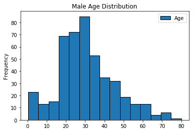

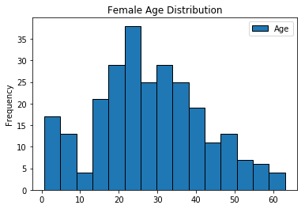

```python
import matplotlib.pyplot as plt

%matplotlib inline

data[['Age']][data['Sex']== 'male'].plot(kind='hist', bins=15, ec='black', title='Male Age Distribution');
data[['Age']][data['Sex']!= 'male'].plot(kind='hist', bins=15, ec='black', title='Female Age Distribution');
```

#### Overlayed Histograms.

In order to produce overlayed histograms, we need to created to separate series of age and pass those into the plotting object. We can do a pivot of the two columns as see below.

```python
age_sex = data[['Age', 'Sex']].pivot(columns='Sex', values='Age')

# Notice the Nan values on the pivot
age_sex.head()
```

| Sex | female | male |
| --- | --- | --- |
| 0 | NaN | 22.0 |
| 1 | 38.0 | NaN |
| 2 | 26.0 | NaN |
| 3 | 35.0 | NaN |
| 4 | NaN | 35.0 |

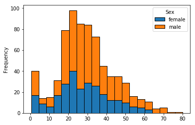

```python
age_sex.plot(kind='hist', ec='black', bins=20, stacked=True)
```

#### Box Plots

Now let's do a box plot to learn of the differences in the distributions.

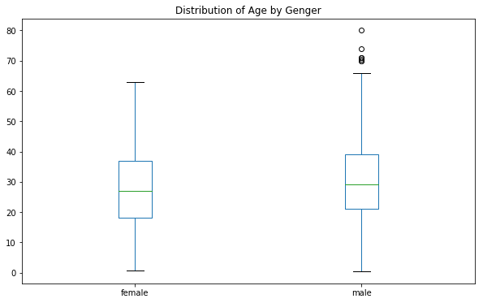

```python
age_sex.plot(kind='box', figsize=(10,6), title='Distribution of Age by Genger')
```